# Ford GoBike Exploration

## by Giulio Tommasino

## Investigation Overview

In this analysis, I would like to figure when and where are most trips taken, and what kind of characteristics are in these locations and time periods. I would also figure out the differences between costumers and subscribers and if there are differences between the characteristics (gender, age) and duration of trips.

## Dataset Overview

Data consists of info about trips taken by service's members, their types, their age, their gender, stations of starting and ending trips, duration of trips etc.

## Most common Gender

Males are the most common users of ford go bike are males. They are the 75% of the total, with female at the 23% and other genders are the 2% of the total

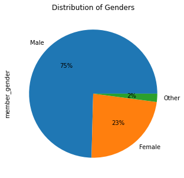

## Distance Traveled and Ride duration

1) The distance travel chart shows that short trips are the most common: The mean length of a ride is 1.48km

2) Most of the rides are less than 20 minutes long, with an average of 11 minutes

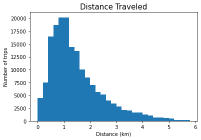

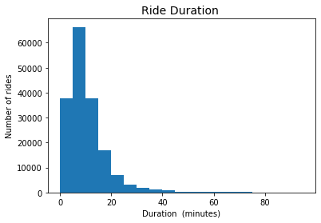

## Weekday usage and day usage

1) Subscribers use the service more often on Monday through Friday, for the customer there is not this difference, since each day has approximatly the same number of trips. It is clear to see that the subscribers use the service a lot more than customer.

2) For costumers the period between 15-23 was the one with the more usage of the service, while for subscribers there isn't such period, instead there is a periodicity of 5 days every 7 days. This is in accordance of the previous chart.

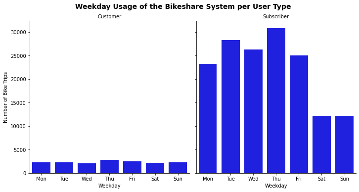

[figure not shown]

## Average distance between subscribers and costumers

Costumers take longer rides than subscribers. The mean distance for subscribers is 1.46 km , and the mean for costumers is 1.67 km.

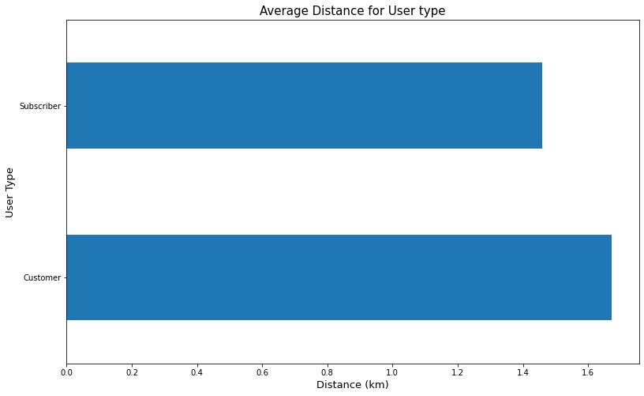

## Usage of the Bikeshare system per User type and Gender

This chart shows how each gender follow a similar pattern .

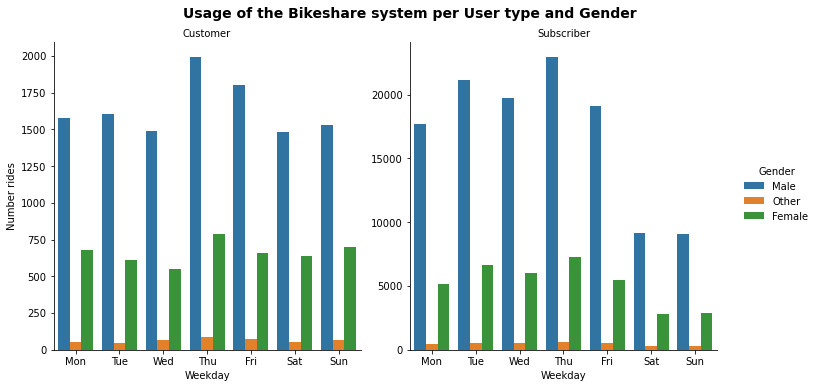